# Effects of MPA designation and fishing pressure on the California spiny lobster (*Panulirus interruptus*)

Joanna Tang, Michelle Lee, & Rachel Behm

19 November 2018

# INTRODUCTION

The California spiny lobster (*Panulirus interruptus*) is one of the most commercially and economically important lobsters in their native range off the American West Coast<sup>1</sup>. The California Department of Fish and Wildlife (CDFW) estimate that nearly 600,000 individual spiny lobsters were harvested (both recreational and commercial) in the first half of the 2008-2009 season<sup>2</sup>. This number is, on average, half the total harvest from Mexico<sup>3</sup>. Given their economic importance, there are heavy restrictions on the fish season by both the CDFW and the Mexican government, with set harvest season dates, catch limits, and size restrictions (greater than 82.5-82.6 mm). Moreover, in 2012, Marine Protected Area (MPA) sites were established off the coast of California–excluding fishing activity for the protection of natural and cultural resources. These restrictions insure the sustainability of the fishery and the health of the kelp forest ecosystem in which they live and provide a unique opportunity to understand the direct impacts on spiny lobster populations.

While the California spiny lobster remains an important fishery, the species also plays an integral part in the marine communities of the giant kelp forest. *P. interruptus* is not only an important food source for many predatory species such as the California sheephead, giant sea bass, cabezone, and several species of shark, but it is also a vital predator of sea urchins, clams, muscles, and worms. Given their important role in maintaining ecosystem balance in the kelp forests off the Pacific coast, understanding the human impacts on this species will allow us to better predict the health of these kelp forest ecosystems.

MPAs, like those off the coast of California, have been established across the United States marine areas in order to protect ecosystems, preserve cultural resources, and sustain fishery populations<sup>4</sup>. Studies have shown that the implementation of these protected areas have consistently increased the biomass of fished species both inside and outside of MPAs, indicating that these sites, overall, have improved the robustness and health of marine organisms<sup>5</sup>. For many fished species, like the spiny lobster, these biomass increases have important implications for the health and reproductive success as species typically reach sexual maturity with at a certain size. Thus, understanding the direct impacts of MPAs on spiny lobster abundance and size in relation to fishing pressure will allow us to foreshadow the future of the species and the ecosystems where they live.

Here we will compare California spiny lobster catch and size in the Santa Barbara Channel from 2012 to 2017 to better understand how MPAs affect the species and the giant kelp ecosystem. These data were collected by the Santa Barbara Coast Long Term Ecological Research Program (SBC LTER) as an ongoing effort to monitor the impacts of management on marine habitats.

# METHODS

## *Data Collection*

Lobster size, abundance, and fishing pressure of *P. interruptus* were collected from 2012-2017 at five SBC LTER Sites off the mainland coast of the Santa Barbara Channel: Arroyo Quemado (AQUE), Naples Reef (NAPL), Mohawk Reef (MOHK), Isla Vista (IVEE), and Carpinteria (CARP). Two of the sites (NAPL and IVEE) are located in or near CDFW MPAs, while the other three (AQUE, MOHK, and CARP) are not. Abundance and size data were collected annually by divers in the late summer before the start of the fishing season. Fishing pressure was determined by counting the number of commerical trap floats. Data were collected every two to four weeks during the lobster fishing season (October to March)<sup>6</sup>.

## *Statistical Analyses*

All statistical analyses and figures were created in R (version 3.4.2).

*Lobster size across sites*  
To compare lobster size across sites, we used lobster size data collected from all sites for 2017. We then conducted an ANOVA test and a post-hoc Tukey’s HSD test to find differences among sites.

*The affect of MPA status*

To compare lobster sizes between MPA and non-MPA sites, we used size data from 2012 and 2017. First, we tested for normality of data across all sites, and determined that our data are normally distributed. We then proceeded with two-sample, two-tailed t-tests to find differences between 2012 and 2017 lobster sizes at each site.

*Proportion of “legal” lobsters across sites*

In order to test for the proportion of legal-sized lobsters (carapace length over 82.6 mm) at all sites in 2017, we conducted a chi-squared, using lobster size data.

*The affect of MPA status*

To compare lobster sizes between MPA and non-MPA sites, we used size data from 2012 and 2017. First, we tested for normality of data across all sites. For sites with normally distributed data, we tested for equal variances using Levene’s test. We then proceeded with two-sample, two-tailed t-tests. For sites with non-normally distributed data, we used two-sampled, two-tailed Mann-Whitney U tests.

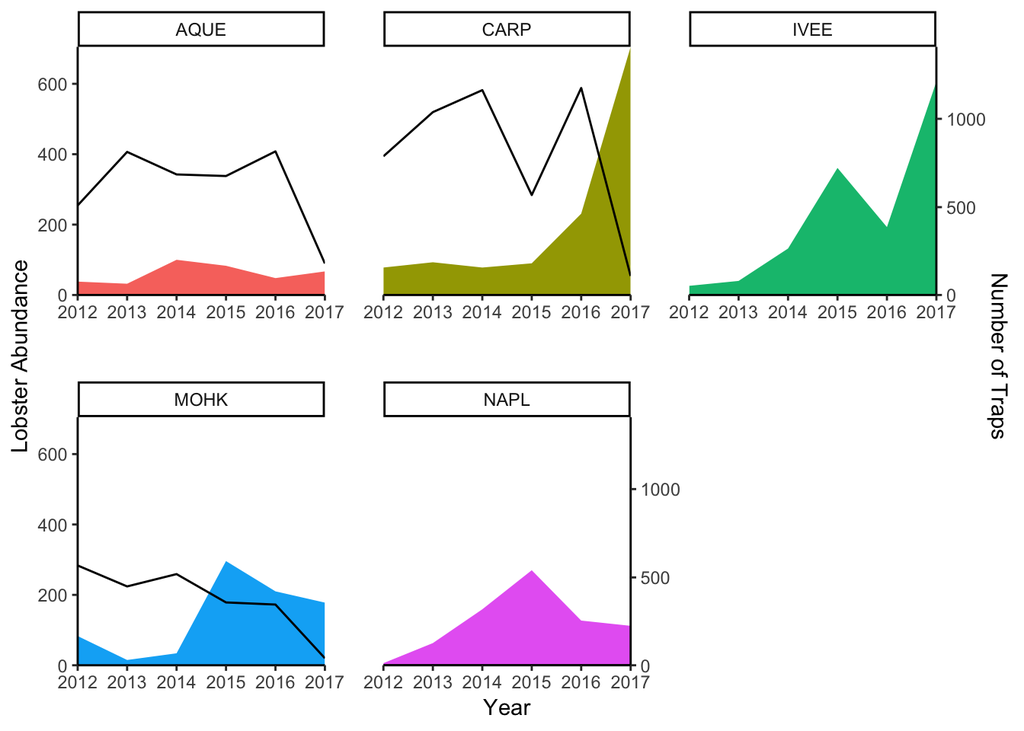

## *Results and Discussion*

*Lobster abundances between MPA and non-MPA sites*

**Figure 1. Spiny lobster abundance and fishing pressure from 2012-2017 across all sites.** *Mean site lobster abundance represented in colored area and fishing pressure in black line for all sites: AQUE, NAPL, MOHK, IVEE, and CARP from 2012-2017. Very generally, we see an increase in lobster abundance across most sites and an overall decrease in fishing pressure in non-MPA sites.*

It is interesting to note that there are not overarching trends that show an association between MPA designation and lobster abundance over time. In 2017, the site with the lowest lobster abundance is a non-MPA (AQUE, 67 lobsters), but CARP, also a non-MPA site, had the highest abundance (705 lobsters). While the site with the second-highest abundance is an MPA (IVEE, 606 lobsters), the other MPA (NAPL) had a lower 2017 lobster abundance (112 lobsters) than two non-MPAs (CARP and MOHK, 705 and 178 lobsters respectively). This shows that fishing pressure and MPA designation alone do not explain lobster abundance.

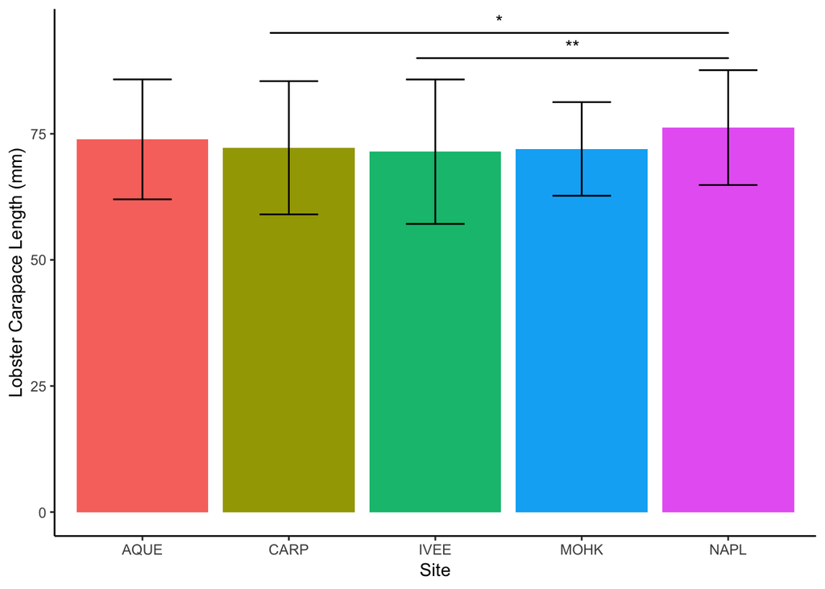

**Figure 2. Spiny lobster size (mm) across all sites (2017).** *Mean spiny lobster carapace size (mm) in 2017 across all five sites: ((n(AQUE) = 67; n(CARP) = 705; n(IVEE) = 606; n(MOHK) = 178; n(NAPL) = 112). Error bars indicate ± 1 standard deviation from the mean. Carapace size only differed between NAPL and both IVEE and CARP. Asterisks represent significant differences between different groups (i.e. one versus 2 asterisks).*

After performing a post-hoc Tukey’s HSD test, we conclude that our significant ANOVA result is driven by differences in mean lobster sizes at NAPL, IVEE, and CARP. Mean lobster size at NAPL differs significantly from CARP (diff = 4.00 mm, *p* = 0.02), Isla Vista (diff = 4.78 mm, *p* < 0.01). MOHK was fairly different when compared to NAPL, but was not statistically significant (diff = 4.23 mm, *p* = 0.06). NAPL also had the greatest mean lobster size (mean±1 standard deviation, 76.23±11.39 mm), suggesting that the lobster population at NAPL is the most robust or healthy. Largely, these differences do not appear to be biologically significant as even the significant differences represent less than 6% of the total carapace size for a theoretical individual.

In contrast to the MPAs, the three non-MPA sites had moderate mean lobster sizes. However, the inverse relationship between abundance and size can still be seen clearly at CARP and AQUE. CARP experienced a drastic increase in abundance in 2016 and 2017, but lobster size in 2017 was relatively small at 72.22±13.21 mm . AQUE had the smallest lobsteer abundance in 2017, but had a larger lobster size of 73.90±11.90 mm. MOHK, which had a moderate abundance in 2017, had a mean lobster size of 72.00±9.28 mm.

Overall, while MPA designation did not uniformly result in larger mean lobster size, a reduction in fishing pressure positively influenced lobster populations by either increasing mean lobster size or increasing abundance. Since mean lobster size and abundance seem to be inversely related, both should be considered when evaluating effects of MPA designation on lobster populations.

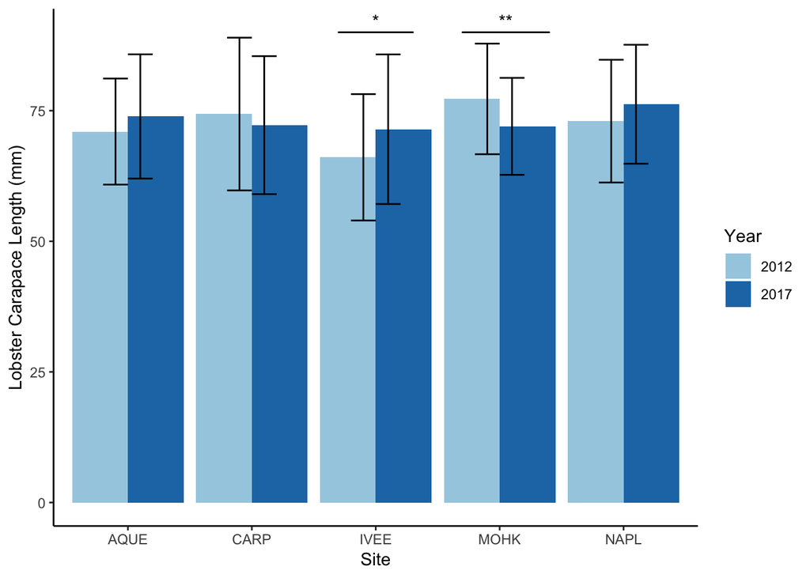

**Figure 3. Spiny Lobster sizes in 2012 versus 2017 across sites.** *Mean spiny lobster carapace length (mm) in 2012 compared to 2017 across all sites. Error bars indicate ± 1 standard deviation from the mean. Carapace size only differed IVEE and MOHK. Asterisks represent significant differences (*p* < 0.05) between different groups (i.e. one versus 2 asterisks).*

*Lobster size over time*

In IVEE and NAPL, the two MPA sites, mean lobster size increased from 2012 to 2017. Isla Vista showed a significant difference in lobster mean sizes between 2012 and 2017 (t (28.09) = -2.20, *p* = 0.04, $\alpha$ = 0.05, Cohen’s *d* = 0.38), with mean lobster size increasing from 66.08±12.09 mm to 71.45±14.32 mm. NAPL also increased over time from 73.00±11.75 mm to 76.23±11.39 mm, although these results were not statistically significant (t (5.52) = -0.66, *p* = 0.54, $\alpha$ = 0.05, Cohen’s *d* = 0.28). Overall, MPA designation appears to positively impact lobster size.

Unlike the MPA sites, there is no consistency between AQUE, MOHK, and CARP, the non-MPA sites, on lobster size differences between 2012 and 2017. AQUE mean lobster size increased from 71.00±10.15 mm to 73.90±11.90 mm, although these resuls were not statistically significant (t (87.35) = -1.32, *p* = 0.19, $\alpha$ = 0.05, Cohen’s *d* = 0.26). CARP, on the other hand, showed a decrease in mean lobster size from 74.36±14.62 mm to 72.23±13.21 mm, although this also was not statistically significant (t (91.46) = 1.23, *p* = 0.22, $\alpha$ = 0.05, Cohen’s *d* = 0.16). MOHK, on the other hand, showed a significant difference in size between years (t (142.79) = 3.89, *p* < 0.01, $\alpha$ = 0.05, Cohen’s *d* = 0.54), with lobster size decreasing from 77.25±10.59 mm to 72.00±9.28 mm. These data also highlight the trend between abundance and mean lobster size. AQUE abundance did not change drastically over time, so neither did its mean lobster size. However, abundance did increase at MOHK and CARP, followed by a decrease in mean lobster size.

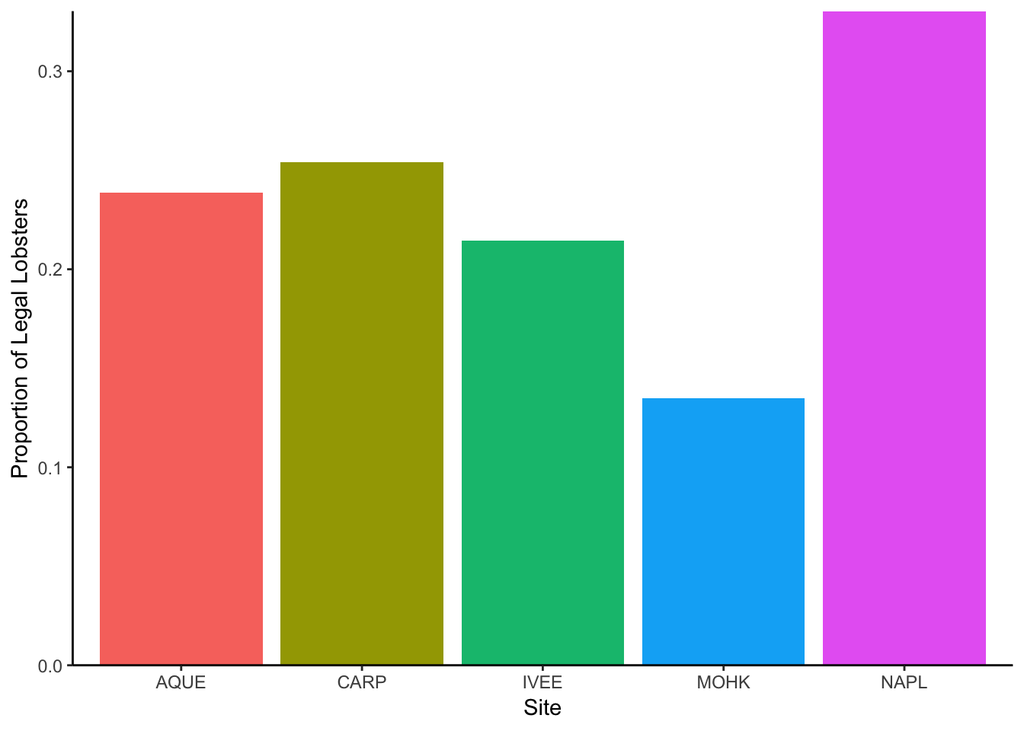

**Figure 4. Proportion of “legal” sized lobsters in 2017 across all sites.** *Proportion of lobsters with carapace size over 82.6 mm (legal minimum catch length) across all sites in 2017. We saw a significant difference in expected proportions (proportions equal) ($\chi$<sup>2</sup>(4) = 18.50, *p* < 0.001, $\alpha$ = 0.05).*

*Proportion of legal lobsters across sites in 2017*

We found proportions of “legal” sized lobsters (>82.6 mm carapace length) across sites in 2017 to be significantly different ($\chi$<sup>2</sup>(4) = 18.50, *p* < 0.001, $\alpha$ = 0.05). Just as we found that NAPL had the greatest mean lobster size across all sites for 2017, we similarly found that NAPL has the greatest proportion of “legal” sized lobsters (33%).

Of the non-MPA sites, 25% of CARP lobsters were “legal” sized, and 24% of AQUE lobsters were “legal” sized. The other MPA, IVEE, had 21% “legal” sized lobsters, while MOHK had the lowest proportion of “legal” sized lobsters (13%).

Again, these data show that there is no clear relationship between MPA designation and lobster size. While the MPA NAPL had the highest proportion of “legal” lobsters, the MPA IVEE had the second-lowest proportion of “legal” lobsters. However, is consistent with our findings above that, although IVEE had smaller lobsters, it had a higher overall abundance of lobsters.

# Conclusions

Across all sites and throughout our analyses, we found that MPA designation is not the primary determinant of lobster size or abundance. Although, the site with the greatest differences with spiny lobster size was an MPA, this trend was largely driven by NAPL and not IVEE. However, if we look at our first analysis of spiny lobster abundance, we can see that abundance showed a nearly reverse trend—where IVEE had one of the highest abundance levels and NAPL did not. Overall, this may indicate some sort of size-abundance trade-off where a particular site may only be able to host a certain biomass of lobster.

Given that spiny lobsters remain, and will remain, economically important for both California and Mexico, understanding the implications of managed and protected lobster habitats is vital for the future of the species and the fishery. <sup>7</sup>

In this study, our response variables are spiny lobster abundance and carapace length (in mm), which are common variables in quantifying community structure. However, our explanatory variables are only MPA designation and fishing pressure, which are not sufficient enough predictors of lobster community to make any reliable claims. Food availability, water quality, predation pressure, temperature, nursury habitat availability<sup>7</sup> and other biotic and abiotic factors must also be taken into account when trying to analyze these different sites. Without including these variables, we can only assume that MPA designation will have some sort of variation even though we can’t quantify it with this data.

# References

1. Holthuis, LB. 1991. “*Panulirus interruptus*”. FAO Species Catalogue, Volume 13. Marine Lobsters of the World. FAO Fisheries Synopsis No. 125. Food and Agriculture Organization. Pp. 142-143. ISBN 95-5-103027-8.
2. Buck, T, Neilson, DJ, Kalvass, P, Barsky, K, Aseltine-Neilson, DA. 2010. A Summary of Preliminary California Spiny Lobster Report Card Data from the First Half of the 2008/2009 Recreational Lobster Season. Administrative Report N. 2010-1. California Department of Fish and Game.
3. Inicia veda de langosta en ambos litorales. 2010. Secretariat of Agriculture, Livestock, Rural Development, Fisheries and Food.
4. Gubbay, S. 1995. Marine protected areas - past, present and future. In: Gubbay S. (eds) Marine Protected Areas. Conservation Biology, vol 5. Springer, Dordrecht.
5. Caselle, JE, Rassweiler, A, Hamilton, SL, and Warner, RR. 2015. Recovery trajectories of kelp forest animals are rapid yet spatially variable across a network of temperate marine protected areas. Scientific Reports: 14102.
6. Reed, D. 2017. SBC LTER: Reef: Abundance, size and fishing effort for California Spiny Lobster (*Panulirus interruptus*), ongoing since 2012. Santa Barbara Coastal Long Term Ecological Research Project. doi:10.6073/pasta/81ce20b29614ec99d85d54907eaa3e8e.
7. Engle, J. M. (1979). Ecology and growth of juvenile California spiny lobster, Panulirus interruptus (Randall) (Doctoral dissertation, University of Southern California).